# Combining Ability Analysis (GCA and SCA) in Maize

A Step-by-Step R Quarto Tutorial for Diallel Crosses

Author

Fausto Rodríguez Zapata, assisted by Antigravity and Claude Code

Published

May 30, 2026

**Source code & data:** https://github.com/faustovrz/gcamoz

> [!NOTE] This step-by-step Quarto notebook is designed for Stelio Boaventura Nuvunga to demonstrate the calculation of General Combining Ability (GCA) and Specific Combining Ability (SCA) using a simulated maize dataset. It starts with the experimental design, simulates realistic yield data for a 7x7 diallel across two environments (representing normal and low-phosphorus conditions), and provides both fixed-effects and mixed-effects R implementations.

# 1 R Environment Setup

To begin, we will load the standard R packages. We use the `tidyverse` suite for data manipulation and visualization, and the `sommer` package (mmer solver), which is the industry standard in R for plant breeding and quantitative genetics, as it supports overlaying female and male random design matrices to estimate GCA.

```r
# Load required libraries
library(tidyverse)    # For data manipulation and plotting
library(sommer)       # Standard plant breeding mixed-model package
library(knitr)        # For beautiful table rendering
library(kableExtra)   # For premium table formatting

# Set seed for perfect reproducibility of the simulated dataset
set.seed(42)
```

# 2 Simulating a 7 × 7 Diallel Maize Dataset

To prepare for real data analysis, we will simulate a **7 × 7 full diallel cross** evaluated for a single trait (**Yield**, in tons per hectare) in **two environments**:

1. **env1:** Normal Phosphorus (optimal conditions)
2. **env2:** Low Phosphorus Stress (phosphorus-deficient conditions)

The trial is laid out as a **Randomized Complete Block Design (RCBD)** with **3 blocks (replications)** in each environment.

## 2.1 Biological Parameters of the Simulation

To make this simulation biologically realistic for maize, we incorporate:

- **A Base Yield ($\mu$):** 8.5 tons/ha.
- **Environmental Stress Effect ($E$):** Normal P (`env1`) adds $+1.0$ t/ha, while Low P (`env2`) reduces yield by $-1.2$ t/ha.
- **Deterministic GCA Effects ($g$):** Parent `Line1` is a highly tolerant CIMMYT line, whereas `Line7` is a highly susceptible local line. The true GCA values are:
  - $\text{Line1} = +1.5$ (superior additive breeding value)
  - $\text{Line2} = +0.8$
  - $\text{Line3} = +0.3$
  - $\text{Line4} = 0.0$
  - $\text{Line5} = -0.4$
  - $\text{Line6} = -0.8$
  - $\text{Line7} = -1.4$ (inferior breeding value)
- **Specific Combining Ability ($s$):** Specific crosses exhibit positive heterosis (e.g., $\text{Line1} \times \text{Line4} = +0.6$), while others show poor compatibility (e.g., $\text{Line2} \times \text{Line6} = -0.5$).
- **Inbreeding Depression (Selfing):** Maize is highly sensitive to selfing. We apply a severe **selfing depression effect of $-1.8$ t/ha** on the diagonal of the diallel (where $\text{female} == \text{male}$).
- **Reciprocal maternal effect:** A small maternal effect is added when `Line3` is used as a female ($+0.25$ t/ha).
- **GCA × Environment Interaction ($G \times E$):** Under Low P stress (`env2`), the tolerance alleles of `Line1` and `Line2` are expressed even more strongly (enhancing their GCA by $+30\%$), whereas susceptible lines perform even worse.
- **Residual Error ($\epsilon$):** Standard plot-level noise ($\sigma_{\epsilon} = 0.35$ t/ha).

## 2.2 R Code to Generate the Dataset

We build the complete dataset of $2 \text{ envs} \times 3 \text{ blocks} \times 49 \text{ crosses} = 294$ plot observations.

```r
# Define parental lines
parents <- paste0("Line", 1:7)
n_parents <- length(parents)

# Define GCA and Environment parameters
gca_effects <- c(Line1=1.5, Line2=0.8, Line3=0.3, Line4=0.0, Line5=-0.4, Line6=-0.8, Line7=-1.4)
env_effects <- c(env1=1.0, env2=-1.2)

# Define SCA matrix (symmetric, with diagonal showing selfing depression)
sca_matrix <- matrix(0, nrow=7, ncol=7, dimnames=list(parents, parents))
sca_matrix["Line1", "Line4"] <- 0.6; sca_matrix["Line4", "Line1"] <- 0.6
sca_matrix["Line2", "Line6"] <- -0.5; sca_matrix["Line6", "Line2"] <- -0.5
sca_matrix["Line3", "Line7"] <- 0.4; sca_matrix["Line7", "Line3"] <- 0.4
sca_matrix["Line5", "Line7"] <- -0.3; sca_matrix["Line7", "Line5"] <- -0.3
diag(sca_matrix) <- -1.8 # Inbreeding depression for selfs

# Build complete observation grid
sim_data <- expand.grid(
  env = c("env1", "env2"),
  block = c("B1", "B2", "B3"),
  female = parents,
  male = parents,
  stringsAsFactors = FALSE
)

# Define unique cross ID (order-independent) and reciprocal indicator
sim_data <- sim_data %>%
  mutate(
    cross = map2_chr(female, male, ~ {
      p_sorted <- sort(c(.x, .y))
      paste(p_sorted[1], p_sorted[2], sep = "_")
    }),
    r_cov = case_when(
      as.numeric(gsub("Line", "", female)) < as.numeric(gsub("Line", "", male)) ~ 1,
      as.numeric(gsub("Line", "", female)) > as.numeric(gsub("Line", "", male)) ~ -1,
      TRUE ~ 0
    )
  )

# Calculate simulated yield using biological parameters
sim_data$yield <- apply(sim_data, 1, function(row) {
  env <- row["env"]
  blk <- row["block"]
  fem <- row["female"]
  mal <- row["male"]
  crs <- row["cross"]

  # Base mean yield
  mu <- 8.5

  # Block effect (unique seed per block nested in environment)
  set.seed(which(parents == fem)*10 + which(parents == mal) + which(c("env1", "env2") == env)*100 + which(c("B1", "B2", "B3") == blk)*1000)
  b_eff <- rnorm(1, mean = 0, sd = 0.20)

  # Environmental effect
  e_eff <- env_effects[env]

  # GCA parental effects
  gca_fem <- gca_effects[fem]
  gca_mal <- gca_effects[mal]

  # SCA effect
  sca_val <- sca_matrix[fem, mal]

  # GCA x Env interaction (Low P stress amplifies GCA effects by 30%)
  ge_fem <- if(env == "env2") gca_fem * 0.3 else -gca_fem * 0.3
  ge_mal <- if(env == "env2") gca_mal * 0.3 else -gca_mal * 0.3

  # SCA x Env interaction (specific hybrid adaptability)
  se_val <- rnorm(1, mean = 0, sd = 0.12)

  # Reciprocal maternal effect (positive maternal effect for Line3)
  r_val <- if(fem != mal) {
    mat_eff <- 0
    if(fem == "Line3") mat_eff <- mat_eff + 0.25
    if(mal == "Line3") mat_eff <- mat_eff - 0.25
    mat_eff
  } else 0

  # Residual Plot Error
  err <- rnorm(1, mean = 0, sd = 0.35)

  # Combine to get phenotypic yield
  y <- mu + e_eff + b_eff + gca_fem + gca_mal + sca_val + ge_fem + ge_mal + se_val + r_val + err
  return(round(y, 3))
})

# Display first few rows of the generated dataset
kable(head(sim_data, 10), caption = "First 10 Observations of the Simulated Maize Diallel Dataset") %>%
  kable_styling(bootstrap_options = c("striped", "hover", "condensed"))
```

First 10 Observations of the Simulated Maize Diallel Dataset

| env | block | female | male | cross | r_cov | yield |
| --- | --- | --- | --- | --- | --- | --- |
| env1 | B1 | Line1 | Line1 | Line1_Line1 | 0 | 10.165 |
| env2 | B1 | Line1 | Line1 | Line1_Line1 | 0 | 9.152 |
| env1 | B2 | Line1 | Line1 | Line1_Line1 | 0 | 9.861 |
| env2 | B2 | Line1 | Line1 | Line1_Line1 | 0 | 9.889 |
| env1 | B3 | Line1 | Line1 | Line1_Line1 | 0 | 10.408 |
| env2 | B3 | Line1 | Line1 | Line1_Line1 | 0 | 9.851 |
| env1 | B1 | Line2 | Line1 | Line1_Line2 | -1 | 11.245 |
| env2 | B1 | Line2 | Line1 | Line1_Line2 | -1 | 10.065 |
| env1 | B2 | Line2 | Line1 | Line1_Line2 | -1 | 10.875 |
| env2 | B2 | Line2 | Line1 | Line1_Line2 | -1 | 9.415 |

# 3 Exploratory Data Analysis & Visualizations

Before running mathematical models, we visualize the dataset to verify that the simulation reflects biological realities (e.g., lower yields in `env2`, inbreeding depression in selfs, and positive GCA in `Line1`).

## 3.1 Diallel Cross Yield Grid

Let’s construct a 7x7 grid of mean yields across all replications and environments to inspect the crossing table.

```r
# Calculate mean yield for each female x male combination across all blocks and envs
diallel_summary <- sim_data %>%
  group_by(female, male) %>%
  summarize(mean_yield = round(mean(yield), 2), .groups = 'drop') %>%
  pivot_wider(names_from = male, values_from = mean_yield)

kable(diallel_summary, caption = "7x7 Maize Diallel Mean Yield Grid (Combined Environments, tons/ha)") %>%
  kable_styling(bootstrap_options = c("striped", "hover", "bordered")) %>%
  row_spec(0, bold = TRUE, background = "#cc0000", color = "white")
```

7x7 Maize Diallel Mean Yield Grid (Combined Environments, tons/ha)

| female | Line1 | Line2 | Line3 | Line4 | Line5 | Line6 | Line7 |
| --- | --- | --- | --- | --- | --- | --- | --- |
| Line1 | 9.89 | 10.68 | 9.80 | 10.55 | 9.65 | 9.11 | 8.49 |
| Line2 | 10.53 | 8.15 | 9.45 | 8.93 | 8.91 | 7.77 | 7.98 |
| Line3 | 10.52 | 10.10 | 7.22 | 9.12 | 8.50 | 8.27 | 7.72 |
| Line4 | 10.57 | 9.31 | 8.22 | 6.51 | 7.77 | 7.44 | 7.07 |
| Line5 | 9.73 | 8.68 | 8.15 | 8.06 | 5.78 | 7.32 | 6.37 |
| Line6 | 9.25 | 7.86 | 7.87 | 7.27 | 7.16 | 5.28 | 6.11 |
| Line7 | 8.88 | 7.75 | 7.65 | 6.61 | 6.17 | 6.04 | 3.77 |

## 3.2 Performance Across Environments

Let’s plot parental and hybrid yields across the two environments to see the impact of Low Phosphorus stress (`env2`) and check for GCA-by-environment interactions.

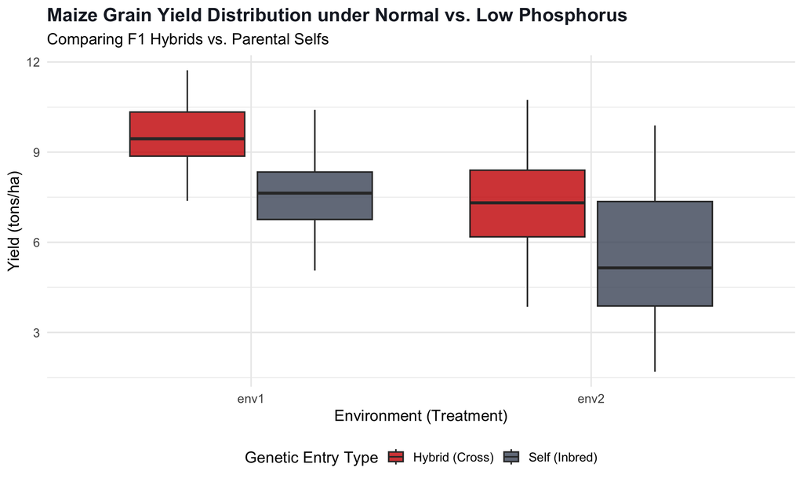

```r
# Classify entries as Hybrid or Self
sim_data_plot <- sim_data %>%
  mutate(Type = if_else(female == male, "Self (Inbred)", "Hybrid (Cross)"))

# Plot yields
ggplot(sim_data_plot, aes(x = env, y = yield, fill = Type)) +
  geom_boxplot(outlier.color = "red", alpha = 0.8) +
  scale_fill_manual(values = c("Hybrid (Cross)" = "#cc0000", "Self (Inbred)" = "#4a5568")) +
  labs(
    title = "Maize Grain Yield Distribution under Normal vs. Low Phosphorus",
    subtitle = "Comparing F1 Hybrids vs. Parental Selfs",
    x = "Environment (Treatment)",
    y = "Yield (tons/ha)",
    fill = "Genetic Entry Type"
  ) +
  theme_minimal(base_size = 14) +
  theme(
    plot.title = element_text(face = "bold", color = "#1a202c"),
    legend.position = "bottom"
  )
```

# 4 Fixed-Effects Calculations: Griffing’s Method 1

In quantitative genetics, **Griffing’s Method 1** (incorporating parents, $F_1$ hybrids, and reciprocal crosses) is the classical fixed-effects method used to partition family means into general combining ability (GCA), specific combining ability (SCA), and reciprocal effects.

We will demonstrate the direct arithmetic calculations from family means. This provides Stelio with an intuitive, hands-on understanding of the underlying genetic algebra before using mixed-model solvers.

## 4.1 Arithmetic Formulas

Let $Y_{ij}$ be the mean of the cross between female $i$ and male $j$ across replications and environments.

- **Grand Mean ($\mu$):** The overall mean of the $p \times p$ diallel table.
  $$\bar{Y}_{..} = \frac{1}{p^2} \sum_{i} \sum_{j} \bar{Y}_{ij}$$
- **Parental Average Means:** The row mean ($\bar{Y}_{i.}$) and column mean ($\bar{Y}_{.i}$) represent the average performance of parent $i$ as a female and male, respectively.
- **GCA Effect of Parent $i$ ($g_i$):**
  $$g_i = \frac{\bar{Y}_{i.} + \bar{Y}_{.i}}{2} - \bar{Y}_{..}$$
- **Reciprocal Effect of Cross $ij$ ($r_{ij}$):**
  $$r_{ij} = \frac{\bar{Y}_{ij} - \bar{Y}_{ji}}{2}$$
- **SCA Effect of Cross $ij$ ($s_{ij}$):**
  $$s_{ij} = \frac{\bar{Y}_{ij} + \bar{Y}_{ji}}{2} - g_i - g_j - \bar{Y}_{..} \quad (\text{for } i \neq j)$$
  $$s_{ii} = \bar{Y}_{ii} - 2g_i - \bar{Y}_{..} \quad (\text{for selfs } i = j)$$

## 4.2 Direct R Implementation

Let’s compute these values arithmetically using the simulated dataset.

```r
# 1. Calculate family means across all observations
family_means <- sim_data %>%
  group_by(female, male) %>%
  summarize(mean_yield = mean(yield), .groups = 'drop')

# 2. Convert to a 7x7 matrix for matrix operations
Y_matrix <- matrix(0, nrow = n_parents, ncol = n_parents, dimnames = list(parents, parents))
for(i in 1:nrow(family_means)) {
  Y_matrix[family_means$female[i], family_means$male[i]] <- family_means$mean_yield[i]
}

# 3. Compute Grand Mean
mu_hat <- mean(Y_matrix)

# 4. Compute Row and Column Means
row_means <- rowMeans(Y_matrix)
col_means <- colMeans(Y_matrix)

# 5. Calculate GCA effects
gca_effects_fixed <- 0.5 * (row_means + col_means) - mu_hat

# 6. Calculate Reciprocal effects
recip_effects_fixed <- matrix(0, nrow = n_parents, ncol = n_parents, dimnames = list(parents, parents))
for(i in 1:n_parents) {
  for(j in 1:n_parents) {
    recip_effects_fixed[i, j] <- 0.5 * (Y_matrix[i, j] - Y_matrix[j, i])
  }
}

# 7. Calculate SCA effects
sca_effects_fixed <- matrix(0, nrow = n_parents, ncol = n_parents, dimnames = list(parents, parents))
for(i in 1:n_parents) {
  for(j in 1:n_parents) {
    if(i == j) {
      # Selfs
      sca_effects_fixed[i, j] <- Y_matrix[i, j] - (2 * gca_effects_fixed[i]) - mu_hat
    } else {
      # Crosses
      sca_effects_fixed[i, j] <- 0.5 * (Y_matrix[i, j] + Y_matrix[j, i]) - gca_effects_fixed[i] - gca_effects_fixed[j] - mu_hat
    }
  }
}

# Print the calculated GCA effects in a premium table
gca_fixed_df <- tibble(
  Parent = names(gca_effects_fixed),
  True_GCA = gca_effects[Parent],
  Estimated_GCA_Fixed = round(gca_effects_fixed, 4)
)

kable(gca_fixed_df, caption = "Arithmetically Calculated GCA Effects (Griffing Method 1)") %>%
  kable_styling(bootstrap_options = c("striped", "hover", "condensed"))
```

Arithmetically Calculated GCA Effects (Griffing Method 1)

| Parent | True_GCA | Estimated_GCA_Fixed |
| --- | --- | --- |
| Line1 | 1.5 | 1.6610 |
| Line2 | 0.8 | 0.7115 |
| Line3 | 0.3 | 0.3952 |
| Line4 | 0.0 | -0.0249 |
| Line5 | -0.4 | -0.4470 |
| Line6 | -0.8 | -0.8743 |
| Line7 | -1.4 | -1.4214 |

> [!TIP] Notice how close the arithmetically estimated GCA effects are to the true programmed parameters! This illustrates the robustness of Griffing’s arithmetic approach in balanced diallel experiments.

# 5 Mixed-Effects Calculations: Overlay Matrix Modeling

While fixed-effects arithmetic is excellent for balanced trials, modern breeding relies on **Linear Mixed Models (LMMs)**. Mixed models:

1. Handle unbalanced datasets (e.g., missing crosses).
2. Incorporate pedigree relationship matrices ($A$-matrix).
3. Directly estimate genetic variance components ($\sigma^2_A$ and $\sigma^2_D$).
4. Shrink predictions (BLUPs) to minimize prediction errors.

## 5.1 The Challenge of Diallel Mixed Models in R

In a diallel design, the same individual appears as both `female` and `male`.

- If we fit standard random effects like `(1|female) + (1|male)` in `lme4`, the software treats them as two completely separate variables, yielding separate female and male variance components and GCA predictions.
- To estimate a single, consistent GCA effect for each parent, we must **overlay** the random incidence matrices $Z_{\text{female}}$ and $Z_{\text{male}}$ so that the statistical model restricts their distributions to be identical.

## 5.2 Option A: Elegant Mixed Modeling with `sommer`

The R package `sommer` has a built-in `overlay()` function designed specifically for overlaying genetic design matrices, functioning identically to ASReml’s `and()` functionality.

We will fit the mixed model for **`env2` (Low Phosphorus Stress)**.

```r
# Subset data for the Low Phosphorus environment (env2)
data_env2 <- sim_data %>%
  filter(env == "env2") %>%
  mutate(
    female = as.factor(female),
    male = as.factor(male),
    cross = as.factor(cross),
    block = as.factor(block)
  )

# Fit mixed model in sommer
# yield = fixed intercept + random overlaid GCA + random SCA (cross) + random block
fit_env2 <- mmer(
  fixed = yield ~ 1,
  random = ~ overlay(female, male) + cross + block,
  data = data_env2,
  verbose = FALSE
)

# Extract variance components
var_comps <- summary(fit_env2)$varcomp
kable(var_comps, caption = "Estimated Variance Components in Low Phosphorus (env2)") %>%
  kable_styling(bootstrap_options = c("striped", "hover"))
```

Estimated Variance Components in Low Phosphorus (env2)

|  | VarComp | VarCompSE | Zratio | Constraint |
| --- | --- | --- | --- | --- |
| overlay(female, male).yield-yield | 1.6390723 | 0.9950059 | 1.6472990 | Positive |
| cross.yield-yield | 0.6993348 | 0.2305159 | 3.0337806 | Positive |
| block.yield-yield | 0.0079673 | 0.0129835 | 0.6136524 | Positive |
| units.yield-yield | 0.2444660 | 0.0319699 | 7.6467488 | Positive |

## 5.3 Extracting GCA BLUPs (sommer)

We extract the General Combining Ability predictions (BLUPs) for each of the 7 parents.

```r
# Extract GCA random effect predictions (BLUPs)
gca_blups <- fit_env2$U$`overlay(female, male)`$yield

# Clean up names to get Line1, Line2, etc.
gca_blups_df <- tibble(
  Parent = gsub("overlay\\(female, male\\)", "", names(gca_blups)),
  GCA_BLUP = round(as.numeric(gca_blups), 4)
)

kable(gca_blups_df, caption = "General Combining Ability (GCA) BLUPs under Low Phosphorus Stress") %>%
  kable_styling(bootstrap_options = c("striped", "hover", "condensed"))
```

General Combining Ability (GCA) BLUPs under Low Phosphorus Stress

| Parent | GCA_BLUP |
| --- | --- |
| Line1 | 1.9875 |
| Line2 | 0.9375 |
| Line3 | 0.4236 |
| Line4 | -0.0743 |
| Line5 | -0.5050 |
| Line6 | -1.0307 |
| Line7 | -1.7386 |

> [!NOTE] `Line1` and `Line2` have strong positive GCA BLUPs under Low P stress, indicating they carry superior, inheritable alleles for phosphorus efficiency that they transmit reliably to their offspring. Conversely, `Line7` is highly susceptible.

# 6 Calculations for Specific Combining Ability (SCA)

While GCA represents parental additive values, the Specific Combining Ability (SCA) represents **dominance deviations** from the expected parental sum, representing how specific cross combinations perform compared to expectations.

## 6.1 Reconstructing SCA Matrix

We extract the random cross effects from our mixed model. These represent the SCA predictions. We format them into a symmetric 7x7 matrix.

```r
# Extract SCA random effects (cross)
sca_blups <- fit_env2$U$cross$yield

# Build SCA table
sca_df <- tibble(
  Cross = gsub("cross", "", names(sca_blups)),
  SCA_BLUP = as.numeric(sca_blups)
)

# Parse female/male from cross name to form a symmetric matrix
sca_matrix_blup <- matrix(0, nrow=7, ncol=7, dimnames=list(parents, parents))

for(i in 1:nrow(sca_df)) {
  cross_name <- sca_df$Cross[i]
  pts <- strsplit(cross_name, "_")[[1]]
  p1 <- pts[1]
  p2 <- pts[2]
  val <- sca_df$SCA_BLUP[i]

  sca_matrix_blup[p1, p2] <- val
  sca_matrix_blup[p2, p1] <- val
}

kable(round(sca_matrix_blup, 4), caption = "Symmetric 7x7 Specific Combining Ability (SCA) BLUP Matrix (env2)") %>%
  kable_styling(bootstrap_options = c("striped", "hover", "bordered")) %>%
  row_spec(0, bold = TRUE, background = "#4a5568", color = "white")
```

Symmetric 7x7 Specific Combining Ability (SCA) BLUP Matrix (env2)

|  | Line1 | Line2 | Line3 | Line4 | Line5 | Line6 | Line7 |
| --- | --- | --- | --- | --- | --- | --- | --- |
| Line1 | -1.0986 | 0.3397 | 0.1823 | 1.0663 | 0.6577 | 0.3065 | 0.4926 |
| Line2 | 0.3397 | -0.8968 | 0.7075 | 0.4170 | 0.4338 | -0.1694 | 0.4651 |
| Line3 | 0.1823 | 0.7075 | -1.2182 | 0.2462 | 0.3085 | 0.5258 | 0.6467 |
| Line4 | 1.0663 | 0.4170 | 0.2462 | -1.2817 | 0.2906 | 0.3036 | 0.2080 |
| Line5 | 0.6577 | 0.4338 | 0.3085 | 0.2906 | -1.1938 | 0.4054 | 0.0761 |
| Line6 | 0.3065 | -0.1694 | 0.5258 | 0.3036 | 0.4054 | -0.9888 | 0.1658 |
| Line7 | 0.4926 | 0.4651 | 0.6467 | 0.2080 | 0.0761 | 0.1658 | -1.3981 |

# 7 Calculating Breeding Values (BV) and Genotypic Values (GV)

A key task for breeding students is to calculate and distinguish the **Breeding Value (BV)** and the **Genotypic Value (GV)** of individual crosses.

According to Chapter 5 of Isik et al. (2017):

1. **Expected Breeding Value ($BV$):** The sum of the parent general combining abilities. Breeding value is completely additive and determines the response to selection when parents are recombined:
   $$BV_{\text{Cross } AB} = g_A + g_B$$
2. **Genotypic Value ($GV$):** The total genetic value of the cross, equal to the Breeding Value plus the dominance Specific Combining Ability deviation. GV determines the commercial performance of the $F_1$ hybrid:
   $$GV_{\text{Cross } AB} = BV_{\text{Cross } AB} + SCA_{AB} = g_A + g_B + s_{AB}$$

Let’s calculate both for all crosses under Low Phosphorus stress (`env2`) using our mixed model results.

```r
# Calculate BV and GV for all crosses
genetic_values <- expand.grid(Female = parents, Male = parents, stringsAsFactors = FALSE) %>%
  filter(as.numeric(gsub("Line", "", Female)) <= as.numeric(gsub("Line", "", Male))) %>% # unique crosses
  mutate(
    GCA_Female = map_dbl(Female, ~ gca_blups_df$GCA_BLUP[gca_blups_df$Parent == .x]),
    GCA_Male = map_dbl(Male, ~ gca_blups_df$GCA_BLUP[gca_blups_df$Parent == .x]),
    SCA = map2_dbl(Female, Male, ~ sca_matrix_blup[.x, .y]),
    Breeding_Value_BV = GCA_Female + GCA_Male,
    Genotypic_Value_GV = Breeding_Value_BV + SCA
  )

kable(head(genetic_values, 15), caption = "Breeding Values (BV) and Genotypic Values (GV) of Maize Crosses (Top 15)") %>%
  kable_styling(bootstrap_options = c("striped", "hover", "condensed"))
```

| Female | Male | GCA_Female | GCA_Male | SCA | Breeding_Value_BV | Genotypic_Value_GV |
| --- | --- | --- | --- | --- | --- | --- |
| Line1 | Line1 | 1.9875 | 1.9875 | -1.0986286 | 3.9750 | 2.8763714 |
| Line1 | Line2 | 1.9875 | 0.9375 | 0.3397207 | 2.9250 | 3.2647207 |
| Line2 | Line2 | 0.9375 | 0.9375 | -0.8968277 | 1.8750 | 0.9781723 |
| Line1 | Line3 | 1.9875 | 0.4236 | 0.1823176 | 2.4111 | 2.5934176 |
| Line2 | Line3 | 0.9375 | 0.4236 | 0.7075416 | 1.3611 | 2.0686416 |
| Line3 | Line3 | 0.4236 | 0.4236 | -1.2181950 | 0.8472 | -0.3709950 |
| Line1 | Line4 | 1.9875 | -0.0743 | 1.0663459 | 1.9132 | 2.9795459 |
| Line2 | Line4 | 0.9375 | -0.0743 | 0.4170021 | 0.8632 | 1.2802021 |
| Line3 | Line4 | 0.4236 | -0.0743 | 0.2462122 | 0.3493 | 0.5955122 |
| Line4 | Line4 | -0.0743 | -0.0743 | -1.2817258 | -0.1486 | -1.4303258 |
| Line1 | Line5 | 1.9875 | -0.5050 | 0.6577357 | 1.4825 | 2.1402357 |
| Line2 | Line5 | 0.9375 | -0.5050 | 0.4337750 | 0.4325 | 0.8662750 |
| Line3 | Line5 | 0.4236 | -0.5050 | 0.3085001 | -0.0814 | 0.2271001 |
| Line4 | Line5 | -0.0743 | -0.5050 | 0.2905775 | -0.5793 | -0.2887225 |
| Line5 | Line5 | -0.5050 | -0.5050 | -1.1938038 | -1.0100 | -2.2038038 |

# 8 Heritability Estimation from Variance Components

## 8.1 Heritability Formulas for Individuals

From Equation 5.7 and 5.8 in the NCSU curriculum (`isik2017_chapter4.txt`):

- **Additive Variance:** $\sigma^2_A = 4 \times \sigma^2_{GCA}$
- **Dominance Variance:** $\sigma^2_D = 4 \times \sigma^2_{SCA}$
- **Phenotypic Variance among Individuals:**
  $$\sigma^2_{\text{phenotypic}} = 2\sigma^2_{GCA} + \sigma^2_{SCA} + \sigma^2_{\text{residual}}$$
- **Individual Narrow-Sense Heritability ($h^2_i$):**
  $$h^2_i = \frac{\sigma^2_A}{\sigma^2_{\text{phenotypic}}} = \frac{4\sigma^2_{GCA}}{2\sigma^2_{GCA} + \sigma^2_{SCA} + \sigma^2_{\text{residual}}}$$
- **Individual Broad-Sense Heritability ($H^2_{bs}$):**
  $$H^2_{bs} = \frac{\sigma^2_A + \sigma^2_D}{\sigma^2_{\text{phenotypic}}} = \frac{4\sigma^2_{GCA} + 4\sigma^2_{SCA}}{2\sigma^2_{GCA} + \sigma^2_{SCA} + \sigma^2_{\text{residual}}}$$

## 8.2 Heritability of Family Means

For a breeder selecting based on whole-family means:

- **Phenotypic Variance of Full-Sib Family Means ($\sigma^2_{FS}$):**
  $$\sigma^2_{FS} = 2\sigma^2_{GCA} + \sigma^2_{SCA} + \frac{\sigma^2_{\text{residual}}}{r}$$
  where $r = 3$ is the number of replications.
- **Full-Sib Family Heritability ($h^2_{FS}$):**
  $$h^2_{FS} = \frac{2\sigma^2_{GCA}}{\sigma^2_{FS}}$$

## 8.3 Heritability Calculations in R

Let’s execute these calculations in R using the variance components retrieved from `fit_env2`.

```r
# Extract individual variance components from sommer output
var_gca <- var_comps["overlay(female, male):yield:yield", "VarComp"]
var_sca <- var_comps["cross:yield:yield", "VarComp"]
var_res <- var_comps["units:yield:yield", "VarComp"]

# Calculate Genetic Variances
var_A <- 4 * var_gca
var_D <- 4 * var_sca

# Individual Phenotypic Variance
var_phen_ind <- 2 * var_gca + var_sca + var_res

# Calculate Individual Heritabilities
h2_individual_ns <- var_A / var_phen_ind
H2_individual_bs <- (var_A + var_D) / var_phen_ind

# Full-Sib Family Phenotypic Variance (r = 3 blocks)
r_rep <- 3
var_phen_fs <- 2 * var_gca + var_sca + (var_res / r_rep)

# Calculate Family Heritability
h2_family_fs <- (2 * var_gca) / var_phen_fs

# Print results
heritability_results <- tibble(
  Parameter = c(
    "Additive Genetic Variance (Va)",
    "Dominance Genetic Variance (Vd)",
    "Individual Phenotypic Variance (Vp_ind)",
    "Narrow-Sense Individual Heritability (h2_i)",
    "Broad-Sense Individual Heritability (H2_bs)",
    "Narrow-Sense Full-Sib Family Heritability (h2_FS)"
  ),
  Value = round(c(var_A, var_D, var_phen_ind, h2_individual_ns, H2_individual_bs, h2_family_fs), 4)
)

kable(heritability_results, caption = "Estimated Genetic Variances and Heritabilities under Low P Stress") %>%
  kable_styling(bootstrap_options = c("striped", "hover", "condensed"))
```

Estimated Genetic Variances and Heritabilities under Low P Stress

[output not shown]

# 9 Tutorial Summary & Checklist for Stelio

To complete the GCA and SCA analysis for his PhD, Stelio should follow these structured steps:

1. **Format the Dataset:** Ensure column names are set (`env`, `block`, `female`, `male`, `yield`) and that the `cross` field is created in a female/male sorted manner.
2. **Define Reciprocals:** Code a reciprocal covariate (`r_cov` set to $1, -1, 0$) if reciprocal maternal effects are to be analyzed.
3. **Run Griffing’s Arithmetic:** Compute the initial GCA and SCA effects using simple family averages to verify data integrity and get quick fixed-effects results.
4. **Perform Mixed Modeling:** Use the `sommer::mmer` package in R. Fit the model using `overlay(female, male)` for the parental GCA, `cross` for the SCA, and nest blocks within environment (`env:block`).
5. **Extract BLUPs:** Extract the predictions and use the equations:
   - $BV = g_A + g_B$ (for parental selection)
   - $GV = g_A + g_B + s_{AB}$ (for commercial hybrid selection)
6. **Calculate Heritabilities:** Extract variance components to calculate narrow-sense heritability ($h^2$) to evaluate genetic gain potential.